# HW2 - Data Transformation

Author

Jessica Villanueva

```r
library(tidyverse)
library(nycflights13)
```

# Question 1

## 1) Tweak the following R command so it runs.

```
libary(todyverse)
ggplot(dTA = mpg) +
geom_point(maping = aes(x = displ y = hwy)) +
geom_smooth(method = "lm)
```

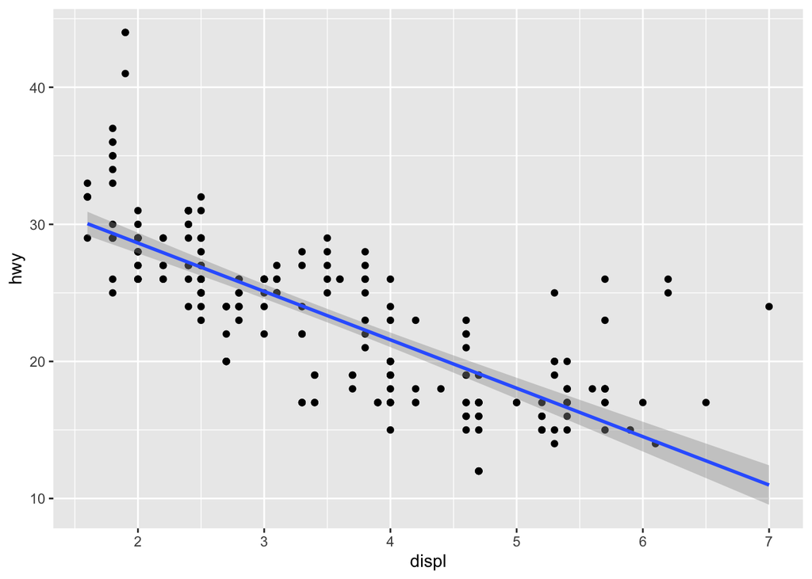

```r
library(tidyverse)
ggplot(
  data = mpg,
  mapping = aes(x = displ, y = hwy)
  ) +
geom_point() +
geom_smooth(method = "lm")
```

# Question 2

### The following questions refer to the `flights`data frame in `nycflights13`package.

### 2.1) In a single pipeline for each condition, find all flights that meet the condition:

#### Had an arrival delay of two or more hours

```r
flights |> filter(arr_delay >= 120)
```

```
# A tibble: 10,200 × 19
    year month   day dep_time sched_dep_time dep_delay arr_time sched_arr_time
   <int> <int> <int>    <int>          <int>     <dbl>    <int>          <int>
 1  2013     1     1      811            630       101     1047            830
 2  2013     1     1      848           1835       853     1001           1950
 3  2013     1     1      957            733       144     1056            853
 4  2013     1     1     1114            900       134     1447           1222
 5  2013     1     1     1505           1310       115     1638           1431
 6  2013     1     1     1525           1340       105     1831           1626
 7  2013     1     1     1549           1445        64     1912           1656
 8  2013     1     1     1558           1359       119     1718           1515
 9  2013     1     1     1732           1630        62     2028           1825
10  2013     1     1     1803           1620       103     2008           1750
# ℹ 10,190 more rows
# ℹ 11 more variables: arr_delay <dbl>, carrier <chr>, flight <int>,
#   tailnum <chr>, origin <chr>, dest <chr>, air_time <dbl>, distance <dbl>,
#   hour <dbl>, minute <dbl>, time_hour <dttm>
```

#### Flew to Houston (`IAH` or `HOU`)

```r
flights |> filter(dest == "IAH" | dest == "HOU")
```

```
# A tibble: 9,313 × 19
    year month   day dep_time sched_dep_time dep_delay arr_time sched_arr_time
   <int> <int> <int>    <int>          <int>     <dbl>    <int>          <int>
 1  2013     1     1      517            515         2      830            819
 2  2013     1     1      533            529         4      850            830
 3  2013     1     1      623            627        -4      933            932
 4  2013     1     1      728            732        -4     1041           1038
 5  2013     1     1      739            739         0     1104           1038
 6  2013     1     1      908            908         0     1228           1219
 7  2013     1     1     1028           1026         2     1350           1339
 8  2013     1     1     1044           1045        -1     1352           1351
 9  2013     1     1     1114            900       134     1447           1222
10  2013     1     1     1205           1200         5     1503           1505
# ℹ 9,303 more rows
# ℹ 11 more variables: arr_delay <dbl>, carrier <chr>, flight <int>,
#   tailnum <chr>, origin <chr>, dest <chr>, air_time <dbl>, distance <dbl>,
#   hour <dbl>, minute <dbl>, time_hour <dttm>
```

#### Were operated by United, American, or Delta

```r
flights |> filter(carrier == "UA" | carrier == "AA" | carrier == "DL")
```

```
# A tibble: 139,504 × 19
    year month   day dep_time sched_dep_time dep_delay arr_time sched_arr_time
   <int> <int> <int>    <int>          <int>     <dbl>    <int>          <int>
 1  2013     1     1      517            515         2      830            819
 2  2013     1     1      533            529         4      850            830
 3  2013     1     1      542            540         2      923            850
 4  2013     1     1      554            600        -6      812            837
 5  2013     1     1      554            558        -4      740            728
 6  2013     1     1      558            600        -2      753            745
 7  2013     1     1      558            600        -2      924            917
 8  2013     1     1      558            600        -2      923            937
 9  2013     1     1      559            600        -1      941            910
10  2013     1     1      559            600        -1      854            902
# ℹ 139,494 more rows
# ℹ 11 more variables: arr_delay <dbl>, carrier <chr>, flight <int>,
#   tailnum <chr>, origin <chr>, dest <chr>, air_time <dbl>, distance <dbl>,
#   hour <dbl>, minute <dbl>, time_hour <dttm>
```

#### Departed in summer (July, August, and September)

```r
flights |> filter(month == 7 | month == 8 | month == 9)
```

```
# A tibble: 86,326 × 19
    year month   day dep_time sched_dep_time dep_delay arr_time sched_arr_time
   <int> <int> <int>    <int>          <int>     <dbl>    <int>          <int>
 1  2013     7     1        1           2029       212      236           2359
 2  2013     7     1        2           2359         3      344            344
 3  2013     7     1       29           2245       104      151              1
 4  2013     7     1       43           2130       193      322             14
 5  2013     7     1       44           2150       174      300            100
 6  2013     7     1       46           2051       235      304           2358
 7  2013     7     1       48           2001       287      308           2305
 8  2013     7     1       58           2155       183      335             43
 9  2013     7     1      100           2146       194      327             30
10  2013     7     1      100           2245       135      337            135
# ℹ 86,316 more rows
# ℹ 11 more variables: arr_delay <dbl>, carrier <chr>, flight <int>,
#   tailnum <chr>, origin <chr>, dest <chr>, air_time <dbl>, distance <dbl>,
#   hour <dbl>, minute <dbl>, time_hour <dttm>
```

#### Arrived more than two hours late, but didn’t leave late

```r
flights |> filter(arr_delay > 120 & dep_delay < 0)
```

```
# A tibble: 26 × 19
    year month   day dep_time sched_dep_time dep_delay arr_time sched_arr_time
   <int> <int> <int>    <int>          <int>     <dbl>    <int>          <int>
 1  2013     1    27     1419           1420        -1     1754           1550
 2  2013    10     7     1357           1359        -2     1858           1654
 3  2013    10    16      657            700        -3     1258           1056
 4  2013    11     1      658            700        -2     1329           1015
 5  2013     3    18     1844           1847        -3       39           2219
 6  2013     4    17     1635           1640        -5     2049           1845
 7  2013     4    18      558            600        -2     1149            850
 8  2013     4    18      655            700        -5     1213            950
 9  2013     5    22     1827           1830        -3     2217           2010
10  2013     6     5     1604           1615       -11     2041           1840
# ℹ 16 more rows
# ℹ 11 more variables: arr_delay <dbl>, carrier <chr>, flight <int>,
#   tailnum <chr>, origin <chr>, dest <chr>, air_time <dbl>, distance <dbl>,
#   hour <dbl>, minute <dbl>, time_hour <dttm>
```

#### Were delayed by at least an hour, but made up over 30 minutes in flight

```r
flights |> filter (dep_delay >= 60 & air_time > 30)
```

```
# A tibble: 26,657 × 19
    year month   day dep_time sched_dep_time dep_delay arr_time sched_arr_time
   <int> <int> <int>    <int>          <int>     <dbl>    <int>          <int>
 1  2013     1     1      811            630       101     1047            830
 2  2013     1     1      826            715        71     1136           1045
 3  2013     1     1      848           1835       853     1001           1950
 4  2013     1     1      957            733       144     1056            853
 5  2013     1     1     1114            900       134     1447           1222
 6  2013     1     1     1120            944        96     1331           1213
 7  2013     1     1     1301           1150        71     1518           1345
 8  2013     1     1     1337           1220        77     1649           1531
 9  2013     1     1     1400           1250        70     1645           1502
10  2013     1     1     1505           1310       115     1638           1431
# ℹ 26,647 more rows
# ℹ 11 more variables: arr_delay <dbl>, carrier <chr>, flight <int>,
#   tailnum <chr>, origin <chr>, dest <chr>, air_time <dbl>, distance <dbl>,
#   hour <dbl>, minute <dbl>, time_hour <dttm>
```

### 2.2) Sort `flights` to find the flights with longest departure delays. Find the flights that left earliest in the morning.

```r
# ????? I'm not entirely sure what this question is asking
flights |> filter(dep_time < 1200) |> arrange(desc(dep_delay), dep_time)
```

```
# A tibble: 131,023 × 19
    year month   day dep_time sched_dep_time dep_delay arr_time sched_arr_time
   <int> <int> <int>    <int>          <int>     <dbl>    <int>          <int>
 1  2013     1     9      641            900      1301     1242           1530
 2  2013     1    10     1121           1635      1126     1239           1810
 3  2013     9    20     1139           1845      1014     1457           2210
 4  2013     7    22      845           1600      1005     1044           1815
 5  2013     4    10     1100           1900       960     1342           2211
 6  2013     6    27      959           1900       899     1236           2226
 7  2013    12     5      756           1700       896     1058           2020
 8  2013     5     3     1133           2055       878     1250           2215
 9  2013     5    19      713           1700       853     1007           1955
10  2013     1     1      848           1835       853     1001           1950
# ℹ 131,013 more rows
# ℹ 11 more variables: arr_delay <dbl>, carrier <chr>, flight <int>,
#   tailnum <chr>, origin <chr>, dest <chr>, air_time <dbl>, distance <dbl>,
#   hour <dbl>, minute <dbl>, time_hour <dttm>
```

```r
# flights with the longest departure delays
arrange(flights, desc(dep_delay))
```

```
# A tibble: 336,776 × 19
    year month   day dep_time sched_dep_time dep_delay arr_time sched_arr_time
   <int> <int> <int>    <int>          <int>     <dbl>    <int>          <int>
 1  2013     1     9      641            900      1301     1242           1530
 2  2013     6    15     1432           1935      1137     1607           2120
 3  2013     1    10     1121           1635      1126     1239           1810
 4  2013     9    20     1139           1845      1014     1457           2210
 5  2013     7    22      845           1600      1005     1044           1815
 6  2013     4    10     1100           1900       960     1342           2211
 7  2013     3    17     2321            810       911      135           1020
 8  2013     6    27      959           1900       899     1236           2226
 9  2013     7    22     2257            759       898      121           1026
10  2013    12     5      756           1700       896     1058           2020
# ℹ 336,766 more rows
# ℹ 11 more variables: arr_delay <dbl>, carrier <chr>, flight <int>,
#   tailnum <chr>, origin <chr>, dest <chr>, air_time <dbl>, distance <dbl>,
#   hour <dbl>, minute <dbl>, time_hour <dttm>
```

```r
# flights that left earliest in the morning (displays all flights from morning until afternoon)
filter(flights, dep_time < 1200) |>
arrange(dep_time)
```

```
# A tibble: 131,023 × 19
    year month   day dep_time sched_dep_time dep_delay arr_time sched_arr_time
   <int> <int> <int>    <int>          <int>     <dbl>    <int>          <int>
 1  2013     1    13        1           2249        72      108           2357
 2  2013     1    31        1           2100       181      124           2225
 3  2013    11    13        1           2359         2      442            440
 4  2013    12    16        1           2359         2      447            437
 5  2013    12    20        1           2359         2      430            440
 6  2013    12    26        1           2359         2      437            440
 7  2013    12    30        1           2359         2      441            437
 8  2013     2    11        1           2100       181      111           2225
 9  2013     2    24        1           2245        76      121           2354
10  2013     3     8        1           2355         6      431            440
# ℹ 131,013 more rows
# ℹ 11 more variables: arr_delay <dbl>, carrier <chr>, flight <int>,
#   tailnum <chr>, origin <chr>, dest <chr>, air_time <dbl>, distance <dbl>,
#   hour <dbl>, minute <dbl>, time_hour <dttm>
```

### 2.3) Sort `flights` to find the fastest flights. (Hint: Try including a math calculation inside of your function.)

```r
mutate(flights, speed = distance / (air_time / 60), .before = 1) |>
  arrange(desc(speed))
```

```
# A tibble: 336,776 × 20
   speed  year month   day dep_time sched_dep_time dep_delay arr_time
   <dbl> <int> <int> <int>    <int>          <int>     <dbl>    <int>
 1  703.  2013     5    25     1709           1700         9     1923
 2  650.  2013     7     2     1558           1513        45     1745
 3  648   2013     5    13     2040           2025        15     2225
 4  641.  2013     3    23     1914           1910         4     2045
 5  591.  2013     1    12     1559           1600        -1     1849
 6  564   2013    11    17      650            655        -5     1059
 7  557.  2013     2    21     2355           2358        -3      412
 8  556.  2013    11    17      759            800        -1     1212
 9  554.  2013    11    16     2003           1925        38       17
10  554.  2013    11    16     2349           2359       -10      402
# ℹ 336,766 more rows
# ℹ 12 more variables: sched_arr_time <int>, arr_delay <dbl>, carrier <chr>,
#   flight <int>, tailnum <chr>, origin <chr>, dest <chr>, air_time <dbl>,
#   distance <dbl>, hour <dbl>, minute <dbl>, time_hour <dttm>
```

### 2.4) Was there a flight on every day of 2013?

```r
flights |>
  group_by(month, day) |>
  summarize(count = n())
```

```
# A tibble: 365 × 3
# Groups:   month [12]
   month   day count
   <int> <int> <int>
 1     1     1   842
 2     1     2   943
 3     1     3   914
 4     1     4   915
 5     1     5   720
 6     1     6   832
 7     1     7   933
 8     1     8   899
 9     1     9   902
10     1    10   932
# ℹ 355 more rows
```

Yes, there was a flight everyday of 2013 because when you group by month and then day, you effectively see all the days of the year. This tibble has 365 rows, which represents everyday of the year. Since there is a value for everyday in the count column, that means there was at least 1 flight in/out of NYC that particular day in 2013.

### 2.5) Which flights traveled the farthest distance? Which traveled the least distance?

```r
# flights that traveled the least distance
select(flights, year:day, carrier, flight, air_time, distance) |>
  arrange(distance, air_time)
```

```
# A tibble: 336,776 × 7
    year month   day carrier flight air_time distance
   <int> <int> <int> <chr>    <int>    <dbl>    <dbl>
 1  2013     7    27 US        1632       NA       17
 2  2013     2     3 EV        4619       21       80
 3  2013     2    12 EV        4619       21       80
 4  2013     1     6 EV        4619       22       80
 5  2013     1    23 EV        4619       23       80
 6  2013     2    10 EV        4619       23       80
 7  2013     2     1 EV        4619       24       80
 8  2013     3    30 EV        4457       24       80
 9  2013     1     7 EV        4619       25       80
10  2013     1    14 EV        4619       25       80
# ℹ 336,766 more rows
```

```r
select(flights, year:day, carrier, flight, air_time, distance) |>
  slice_min(distance, n = 1)
```

```
# A tibble: 1 × 7
   year month   day carrier flight air_time distance
  <int> <int> <int> <chr>    <int>    <dbl>    <dbl>
1  2013     7    27 US        1632       NA       17
```

```r
# flights that traveled the farthest distance
select(flights, year:day, carrier, flight, air_time, distance) |>
  arrange(desc(distance), desc(air_time))
```

```
# A tibble: 336,776 × 7
    year month   day carrier flight air_time distance
   <int> <int> <int> <chr>    <int>    <dbl>    <dbl>
 1  2013     2     6 HA          51      691     4983
 2  2013     3    15 HA          51      686     4983
 3  2013     3    17 HA          51      686     4983
 4  2013     3    16 HA          51      683     4983
 5  2013     2     5 HA          51      679     4983
 6  2013     3    14 HA          51      676     4983
 7  2013    11    20 HA          51      675     4983
 8  2013     4     3 HA          51      671     4983
 9  2013    11    11 HA          51      669     4983
10  2013    11    10 HA          51      667     4983
# ℹ 336,766 more rows
```

```r
select(flights, year:day, carrier, flight, air_time, distance) |>
  slice_max(distance, n = 1) |>
  arrange(desc(air_time))
```

```
# A tibble: 342 × 7
    year month   day carrier flight air_time distance
   <int> <int> <int> <chr>    <int>    <dbl>    <dbl>
 1  2013     2     6 HA          51      691     4983
 2  2013     3    15 HA          51      686     4983
 3  2013     3    17 HA          51      686     4983
 4  2013     3    16 HA          51      683     4983
 5  2013     2     5 HA          51      679     4983
 6  2013     3    14 HA          51      676     4983
 7  2013    11    20 HA          51      675     4983
 8  2013     4     3 HA          51      671     4983
 9  2013    11    11 HA          51      669     4983
10  2013    11    10 HA          51      667     4983
# ℹ 332 more rows
```

### 2.6) Does it matter what order you used `filter()`and `arrange()`if you’re using both? Why/why not? Think about the results and how much work the functions would have to do.

Filter reduces the amount of rows a data set has, so if you call filter first before arrange, arrange has less work to do. If arrange gets called first before filter, arrange sorts the entire data set, even the rows that are not needed, and thus wastes time and/or resources. It is more efficient to filter first, then arrange if you’re using both function calls.

### 2.7) What happens if you specify the name of the same variable multiple times in a `select()` call?

```r
# experiment
select(flights, year, year, year)
```

```
# A tibble: 336,776 × 1
    year
   <int>
 1  2013
 2  2013
 3  2013
 4  2013
 5  2013
 6  2013
 7  2013
 8  2013
 9  2013
10  2013
# ℹ 336,766 more rows
```

```r
select(flights, year, year, day, day)
```

```
# A tibble: 336,776 × 2
    year   day
   <int> <int>
 1  2013     1
 2  2013     1
 3  2013     1
 4  2013     1
 5  2013     1
 6  2013     1
 7  2013     1
 8  2013     1
 9  2013     1
10  2013     1
# ℹ 336,766 more rows
```

```r
select(flights, year, day, year, day)
```

```
# A tibble: 336,776 × 2
    year   day
   <int> <int>
 1  2013     1
 2  2013     1
 3  2013     1
 4  2013     1
 5  2013     1
 6  2013     1
 7  2013     1
 8  2013     1
 9  2013     1
10  2013     1
# ℹ 336,766 more rows
```

In my experiments, I found that a select() call ignores multiple references to the same variable, no matter the order or how many times you references the same variable. It shows only distinct columns.

### 2.8) Rename `air_time` to `air_time_min` to indicate units of measurement and move it to the beginning of the data frame.

```r
rename(flights, air_time_min = air_time) |>
  relocate(air_time_min, .before = 1)
```

```
# A tibble: 336,776 × 19
   air_time_min  year month   day dep_time sched_dep_time dep_delay arr_time
          <dbl> <int> <int> <int>    <int>          <int>     <dbl>    <int>
 1          227  2013     1     1      517            515         2      830
 2          227  2013     1     1      533            529         4      850
 3          160  2013     1     1      542            540         2      923
 4          183  2013     1     1      544            545        -1     1004
 5          116  2013     1     1      554            600        -6      812
 6          150  2013     1     1      554            558        -4      740
 7          158  2013     1     1      555            600        -5      913
 8           53  2013     1     1      557            600        -3      709
 9          140  2013     1     1      557            600        -3      838
10          138  2013     1     1      558            600        -2      753
# ℹ 336,766 more rows
# ℹ 11 more variables: sched_arr_time <int>, arr_delay <dbl>, carrier <chr>,
#   flight <int>, tailnum <chr>, origin <chr>, dest <chr>, distance <dbl>,
#   hour <dbl>, minute <dbl>, time_hour <dttm>
```

# **Question 3**

### 3.1) Which carrier has the worst average delays? Challenge: can you disentangle the effects of bad airports vs. bad carriers? Why/why not? (Hint: think about `flights |> group_by(carrier, dest) |> summarize(n())`)

```r
# I'm also confused with how to approach this, but I'll try my best:

# carriers with the longest avg total delay
group_by(flights, carrier) |>
  summarize(avg_dep_delay = mean(dep_delay, na.rm = TRUE),
            avg_arr_delay = mean(arr_delay, na.rm = TRUE)) |>
  mutate(avg_total_delay = (avg_dep_delay + avg_arr_delay) / 2) |>
  arrange(desc(avg_total_delay))
```

```
# A tibble: 16 × 4
   carrier avg_dep_delay avg_arr_delay avg_total_delay
   <chr>           <dbl>         <dbl>           <dbl>
 1 F9              20.2         21.9             21.1
 2 FL              18.7         20.1             19.4
 3 EV              20.0         15.8             17.9
 4 YV              19.0         15.6             17.3
 5 WN              17.7          9.65            13.7
 6 OO              12.6         11.9             12.3
 7 9E              16.7          7.38            12.1
 8 B6              13.0          9.46            11.2
 9 MQ              10.6         10.8             10.7
10 UA              12.1          3.56             7.83
11 VX              12.9          1.76             7.32
12 DL               9.26         1.64             5.45
13 AA               8.59         0.364            4.48
14 US               3.78         2.13             2.96
15 HA               4.90        -6.92            -1.01
16 AS               5.80        -9.93            -2.06
```

```r
# destination airports with the longest avg total delay
group_by(flights, dest) |>
  summarize(avg_dep_delay = mean(dep_delay, na.rm = TRUE),
            avg_arr_delay = mean(arr_delay, na.rm = TRUE)) |>
  mutate(avg_total_delay = (avg_dep_delay + avg_arr_delay) / 2) |>
  arrange(desc(avg_total_delay))
```

```
# A tibble: 105 × 4
   dest  avg_dep_delay avg_arr_delay avg_total_delay
   <chr>         <dbl>         <dbl>           <dbl>
 1 CAE            35.6          41.8            38.7
 2 TUL            34.9          33.7            34.3
 3 OKC            30.6          30.6            30.6
 4 JAC            26.5          28.1            27.3
 5 TYS            28.5          24.1            26.3
 6 BHM            29.7          16.9            23.3
 7 DSM            26.2          19.0            22.6
 8 MSN            23.6          20.2            21.9
 9 RIC            23.6          20.1            21.9
10 CAK            20.8          19.7            20.3
# ℹ 95 more rows
```

```r
# carriers, grouped by destination, with the longest avg total delay
group_by(flights, carrier, dest) |>
  summarize(avg_dep_delay = mean(dep_delay, na.rm = TRUE),
            avg_arr_delay = mean(arr_delay, na.rm = TRUE)) |>
  mutate(avg_total_delay = (avg_dep_delay + avg_arr_delay) / 2) |>
  arrange(desc(avg_total_delay))
```

```
# A tibble: 314 × 5
# Groups:   carrier [16]
   carrier dest  avg_dep_delay avg_arr_delay avg_total_delay
   <chr>   <chr>         <dbl>         <dbl>           <dbl>
 1 UA      STL            77.5         110              93.8
 2 OO      ORD            67           107              87
 3 OO      DTW            61            68.5            64.8
 4 UA      RDU            60            56              58
 5 EV      PBI            48.7          40.7            44.7
 6 EV      TYS            41.8          41.2            41.5
 7 EV      CAE            36.7          42.8            39.8
 8 EV      TUL            34.9          33.7            34.3
 9 EV      OKC            30.6          30.6            30.6
10 UA      JAC            28.7          29.9            29.3
# ℹ 304 more rows
```

From the first tibble, we can conclude that carrier F9 has the longest delays, on average (considering both arrival and departure delays). F9 also has the greatest average departure and arrival delays individually, compared to the rest of the carriers.

Yes, you can disentangle the effects of bad carriers vs. bad airports. If you compare all three dataframes, the first one showing the average total delay of carriers, the second showing the average total delay of airports, and the third showing the average total delay of each carrier dependent on the destination airport.

For example, in the third tibble we can see that carrier EV shows up frequently in the first 20 rows (about 55%). This indicates that the long departure delays are a result of the carrier rather than the airport. Furthermore, in the second tibble, the airport CAE has the longest average total delay. However if we cross reference it with the third tibble, it only appears once in the first 20 rows–associated with the carrier EV. This may indicate that CAE’s high times in the second tibble are a result of outliers caused by the carrier EV, who has a history of delayed departure and arrival times, and not because the airport itself often has delays.

### 3.2) Find the flights that are most delayed upon departure from each destination.

```r
group_by(flights, dest) |>
  slice_max(dep_delay, n = 1) |>
  relocate(dest, dep_delay)
```

```
# A tibble: 105 × 19
# Groups:   dest [105]
   dest  dep_delay  year month   day dep_time sched_dep_time arr_time
   <chr>     <dbl> <int> <int> <int>    <int>          <int>    <int>
 1 ABQ         142  2013    12    14     2223           2001      133
 2 ACK         219  2013     7    23     1139            800     1250
 3 ALB         323  2013     1    25      123           2000      229
 4 ANC          75  2013     8    17     1740           1625     2042
 5 ATL         898  2013     7    22     2257            759      121
 6 AUS         351  2013     7    10     2056           1505     2347
 7 AVL         222  2013     6    14     1158            816     1335
 8 BDL         252  2013     2    21     1728           1316     1839
 9 BGR         248  2013    12     1     1504           1056     1628
10 BHM         325  2013     4    10       25           1900      136
# ℹ 95 more rows
# ℹ 11 more variables: sched_arr_time <int>, arr_delay <dbl>, carrier <chr>,
#   flight <int>, tailnum <chr>, origin <chr>, air_time <dbl>, distance <dbl>,
#   hour <dbl>, minute <dbl>, time_hour <dttm>
```

### 3.3) How do delays vary over the course of the day. Illustrate your answer with a plot.

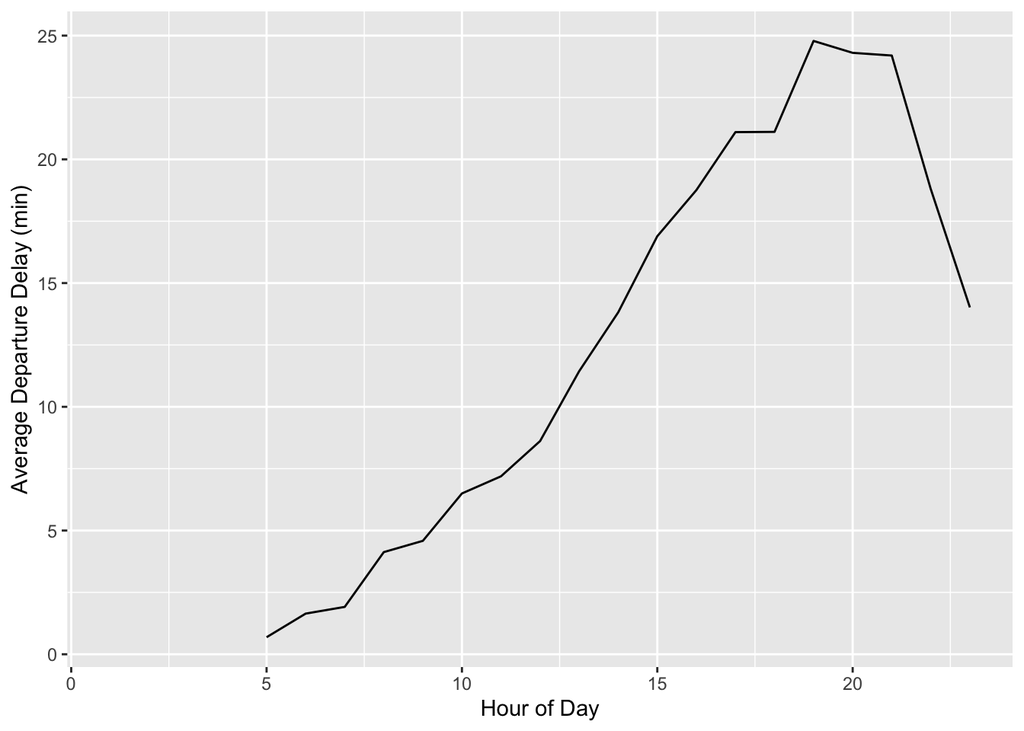

```r
# average length (in minutes) of departure delay per hour of the day
group_by(flights, hour) |>
  summarize(avg_dep_delay = mean(dep_delay, na.rm = TRUE)) |>
  ggplot(
    mapping = aes(x = hour, y = avg_dep_delay)
  ) +
  geom_line() +
  labs(
    x = "Hour of Day", y = "Average Departure Delay (min)"
  )
```

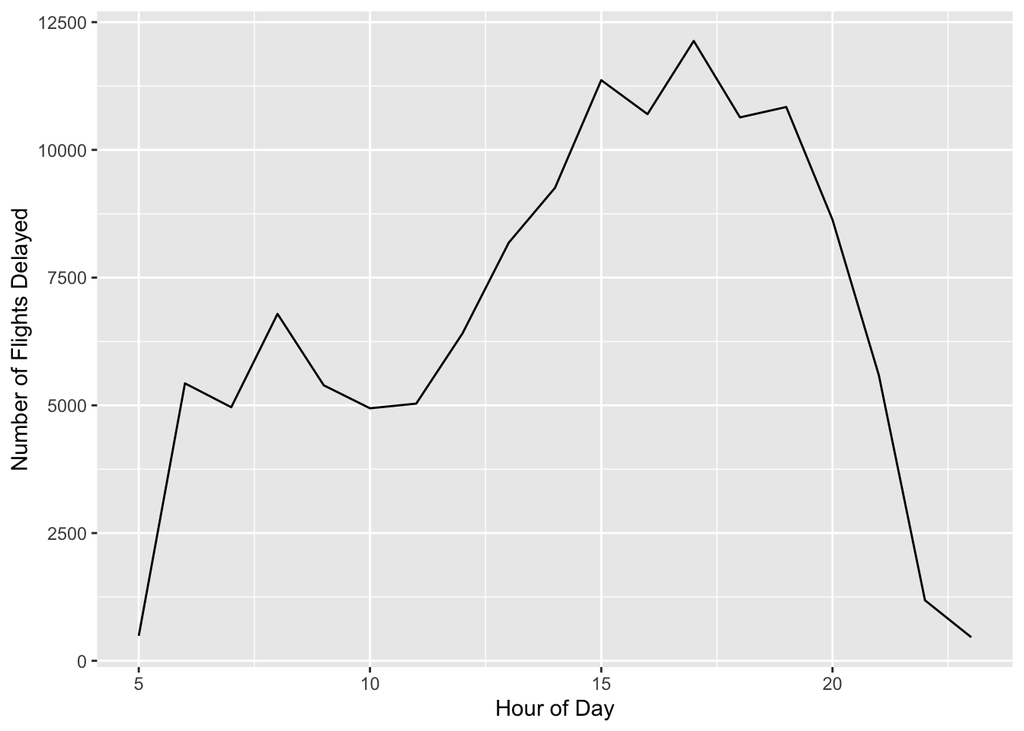

```r
# number of flights that are delayed over the course of the day
group_by(flights, hour) |>
  filter(dep_delay > 0) |>
  summarize(count = n()) |>
  ggplot(
    mapping = aes(x = hour, y = count)
  ) +
  geom_line() +
  labs(
    x = "Hour of Day", y = "Number of Flights Delayed"
  )
```

In the first plot, we can see that as the day progresses, on average, the departure delay increases linearly and peaks around 7:00 PM and 9:00 PM. These times are when you can expect the longest delay in minutes. After 9:00 PM, the length of delay sharply declines.

The second plot illustrates the number of flights that are delayed throughout the course of the day. We can see here that most flights that are delayed depart between 2:00 PM and 8:00 PM. Flights after 9:00 PM have a significantly less chance of being delayed, but that might also be attributed to the number of total flights that leave during that time (the number of total flights is significantly less than in the afternoon).

### 3.4) What happens if you supply a negative `n` to [`slice_min()`](https://dplyr.tidyverse.org/reference/slice.html) and friends?

```r
select(flights, year:day, carrier, flight, air_time, distance)
```

```
# A tibble: 336,776 × 7
    year month   day carrier flight air_time distance
   <int> <int> <int> <chr>    <int>    <dbl>    <dbl>
 1  2013     1     1 UA        1545      227     1400
 2  2013     1     1 UA        1714      227     1416
 3  2013     1     1 AA        1141      160     1089
 4  2013     1     1 B6         725      183     1576
 5  2013     1     1 DL         461      116      762
 6  2013     1     1 UA        1696      150      719
 7  2013     1     1 B6         507      158     1065
 8  2013     1     1 EV        5708       53      229
 9  2013     1     1 B6          79      140      944
10  2013     1     1 AA         301      138      733
# ℹ 336,766 more rows
```

```r
select(flights, year:day, carrier, flight, air_time, distance) |>
  slice_head(n = 5)
```

```
# A tibble: 5 × 7
   year month   day carrier flight air_time distance
  <int> <int> <int> <chr>    <int>    <dbl>    <dbl>
1  2013     1     1 UA        1545      227     1400
2  2013     1     1 UA        1714      227     1416
3  2013     1     1 AA        1141      160     1089
4  2013     1     1 B6         725      183     1576
5  2013     1     1 DL         461      116      762
```

```r
select(flights, year:day, carrier, flight, air_time, distance) |>
  slice_head(n = -5)
```

```
# A tibble: 336,771 × 7
    year month   day carrier flight air_time distance
   <int> <int> <int> <chr>    <int>    <dbl>    <dbl>
 1  2013     1     1 UA        1545      227     1400
 2  2013     1     1 UA        1714      227     1416
 3  2013     1     1 AA        1141      160     1089
 4  2013     1     1 B6         725      183     1576
 5  2013     1     1 DL         461      116      762
 6  2013     1     1 UA        1696      150      719
 7  2013     1     1 B6         507      158     1065
 8  2013     1     1 EV        5708       53      229
 9  2013     1     1 B6          79      140      944
10  2013     1     1 AA         301      138      733
# ℹ 336,761 more rows
```

### 3.5) Explain what `count()` does in terms of the dplyr verbs you just learned. What does the `sort` argument to [`count()`](https://dplyr.tidyverse.org/reference/count.html) do?

Count() tallies the distinct values of a specified data frame, given variables to group by. The sort argument can be assigned a Boolean value, and if true, lists the largest groups/values at the top of the data frame.

# Question 5

### Come up with and answer your own question regarding flights. Answer it using a pipeline with at least 3 steps.

What day of each month has the most flights leaving NYC? What time is the busiest?

```r
# finding the days of each month with the highest number of flights
group_by(flights, month, day) |>
  summarize(count = n()) |>
  slice_max(count) |>
  arrange(desc(count))
```

```
# A tibble: 21 × 3
# Groups:   month [12]
   month   day count
   <int> <int> <int>
 1    11    27  1014
 2     7    11  1006
 3    12     2  1004
 4     8     7  1001
 5     8     8  1001
 6     8    12  1001
 7     9    13   996
 8     9    26   996
 9     9    27   996
10     4    15   995
# ℹ 11 more rows
```

```r
# if we take the day with the most departures, we can find the
# busiest time to catch a flight out of NYC in 2013
filter(flights, month == 11, day == 27) |>
  group_by(hour) |>
  summarize(count = n()) |>
  arrange(desc(count))
```

```
# A tibble: 19 × 2
    hour count
   <dbl> <int>
 1     8    86
 2     6    76
 3     7    70
 4    17    69
 5    15    68
 6    16    67
 7    18    67
 8    19    67
 9    14    63
10    13    62
11     9    58
12    12    55
13    10    54
14    20    52
15    11    46
16    21    37
17    22     8
18     5     5
19    23     4
```

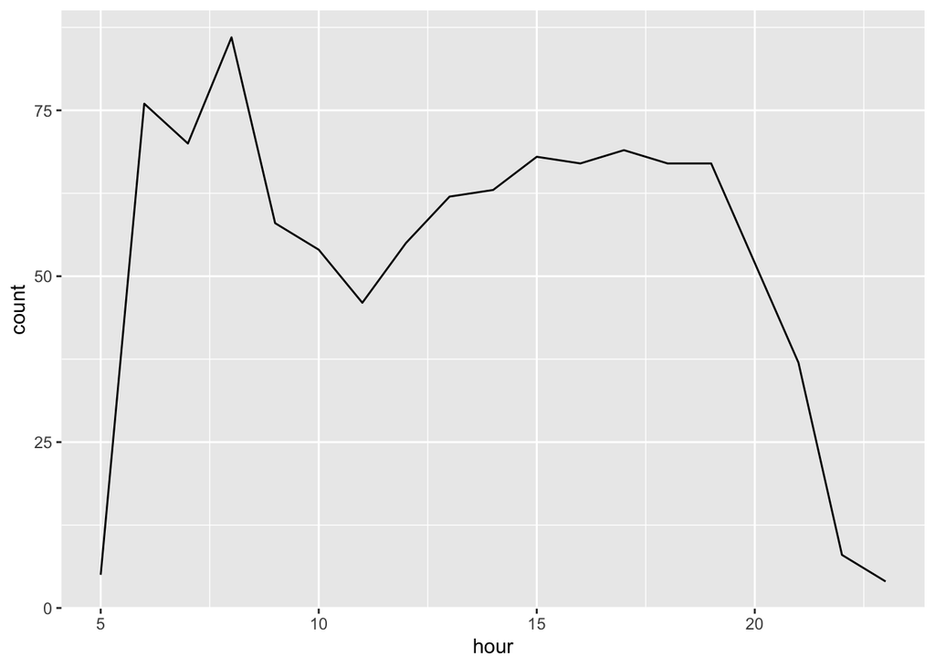

```r
# plotting the data:
filter(flights, month == 11, day == 27) |>
  group_by(hour) |>
  summarize(count = n()) |>
  arrange(desc(count)) |>
  ggplot(
    mapping = aes(x = hour, y = count)
  ) +
  geom_line()
```

The first data frame lists all the days of each month that had the most flights leaving NYC in 2013. It sorted it based on number of flights, so we were able to find that November 27th, 2013 was the day that had the most flights depart from NYC.

In the second data frame, it takes all the flights leaving NYC on November 27th and sorts it by hour according to how many flights departed during that time. Here, we can see that November 27th, 2013 from 6-8 A.M. was the busiest time to catch a flight out of NYC.

In the plot, we can visually see the number of departing flights on Nov. 27th throughout the day. After 8:00 PM, we can observe a sharp decline in departing flights.